# 6.1 À but lucratif (abordable, prix du marché)

# 6.1.3 Mises en chantier par mode d’occupation

*Data source: CMHC Starts and Completions Survey.*

Les mises en chantier montrent des tendances similaires lorsqu’elles sont ventilées par marché cible. Les taux élevés de nouveaux projets de logements destinés à l’accession à la propriété dans les années 1990 et 2000 ont progressivement laissé place aux mises en chantier de logements en copropriété et, plus récemment, à celles de logements locatifs. Looking at five-year moving averages, homeowner starts peaked in 2000-2004 at 1 560 per year. Condominium starts peaked in 2008-2012 at 1 130 per year. And rental starts peaked in 2018-2022 at 1 780 per year.

| Période | Prop.-occ. | Locatif | Copropriété | Coopératif | Total |
| --- | --- | --- | --- | --- | --- |
| 1990-1993 | 1 470 | 316 | 442 | 0 | 2 228 |
| 1994-1998 | 1 057 | 92 | 148 | 0 | 1 297 |
| 1999-2003 | 1 437 | 150 | 572 | 0 | 2 159 |
| 2004-2008 | 1 316 | 804 | 918 | 11 | 3 048 |
| 2009-2013 | 735 | 558 | 1 025 | 9 | 2 327 |
| 2014-2018 | 301 | 658 | 805 | 0 | 1 764 |
| 2019-2023 | 224 | 1 598 | 251 | 0 | 2 074 |

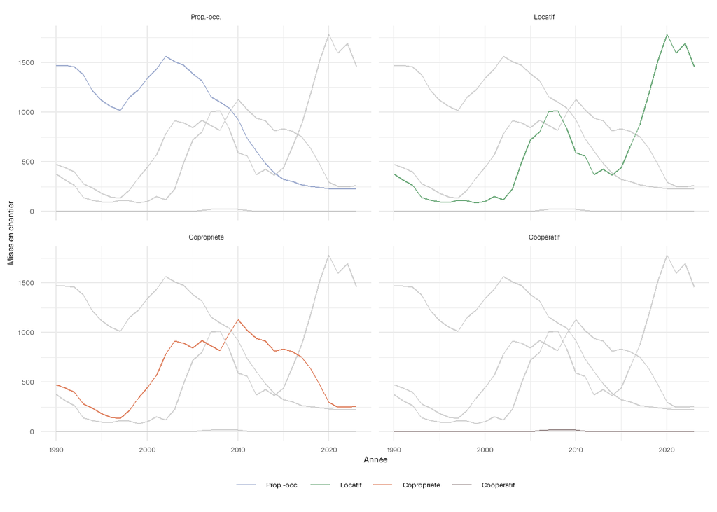

Mirroring the shift discussed in 6.1.2 towards apartment housing starts, sine 2010 an increasingly high percentage of annual housing starts have been intended for the rental market, albeit with a high level of volatility. This trend largely reflects the interaction between a highly cyclical rental construction sector (with peaks in starts in 2007-2008 and 2020), a long-term decline in new starts in the homeownership sector, and the 2000s growth and then 2010s decline in condominium starts.

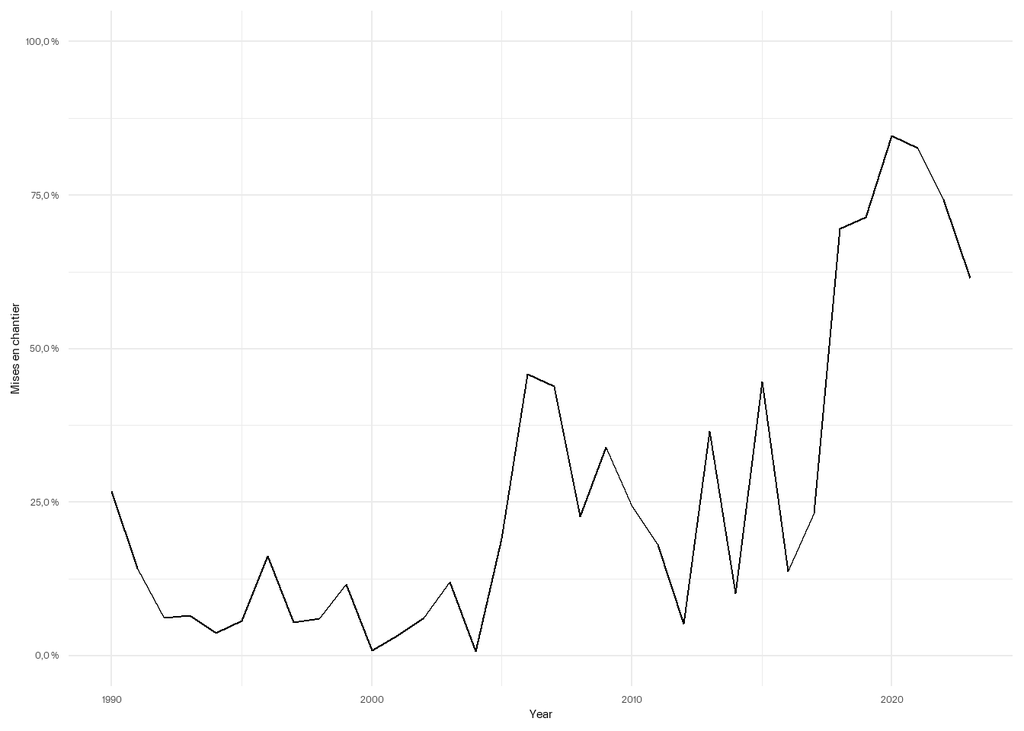